# HW_02

Author

Tyler Gallagher

## Data Wrangling

```r
chs_individual <- read.csv("/Users/TylerGallagher13/Desktop/chs_individual.csv")
chs_regional <- read.csv("/Users/TylerGallagher13/Desktop/chs_regional.csv")
library(dplyr)
```

```r
chs <- merge(chs_individual, chs_regional, by = "townname", all.x = TRUE)
```

```r
head(chs)
```

```
  townname sid male race hispanic    agepft height weight      bmi asthma
1   Alpine 841    1    W        1 10.548939    150     78 15.75758      0
2   Alpine 835    0    W        0 10.099932    143     69 15.33749      0
3   Alpine 838    0    O        1  9.486653    133     62 15.93183      0
4   Alpine 840    0    W        0  9.965777    146     78 16.63283      0
5   Alpine 865    0    W        0 10.039699    162    140 24.24797      1
6   Alpine 867    0    W        1  9.957563    141     94 21.49151      0
  active_asthma father_asthma mother_asthma wheeze hayfever allergy educ_parent
1             0             0             0      0        0       0           5
2             0             0             0      0        0       1           3
3             0             0             0      0        0       0           4
4             0             0             0      0        0       0          NA
5             1             0             0      1        0       1           3
6             0            NA             0      0        0       0           5
  smoke pets gasstove      fev      fvc     mmef pm25_mass pm25_so4 pm25_no3
```

[output cut: 27 more lines]

```r
print(nrow(chs))
```

```
[1] 1200
```

```r
print(nrow(chs_individual))
```

```
[1] 1200
```

There are no duplicates.

```r
summary(chs$bmi)
```

```
   Min. 1st Qu.  Median    Mean 3rd Qu.    Max.    NA's
  11.30   15.78   17.48   18.50   20.35   41.27      89
```

```r
calculate_mode <- function(x) {
  tbl <- table(x)
  mode_value <- as.numeric(names(tbl[tbl == max(tbl)]))
  if (length(mode_value) == 0) return(NA) else return(mode_value)
}
chs <- chs %>%
  group_by(male, hispanic) %>%
  mutate(bmi = ifelse(is.na(bmi), mean(bmi, na.rm = TRUE), bmi))
chs <- chs %>%
  group_by(male, hispanic) %>%
  mutate(smoke = ifelse(is.na(smoke), calculate_mode(smoke), smoke))
chs <- chs %>%
  group_by(male, hispanic) %>%
  mutate(gasstove = ifelse(is.na(gasstove), calculate_mode(gasstove), gasstove))
chs <- ungroup(chs)
```

```r
summary(chs$bmi)
```

```
   Min. 1st Qu.  Median    Mean 3rd Qu.    Max.
  11.30   15.96   17.81   18.50   19.99   41.27
```

```r
chs <- chs %>%
  mutate(obesity_level = case_when(
    bmi < 14 ~ "underweight",
    bmi >= 14 & bmi < 22 ~ "normal",
    bmi >= 22 & bmi <= 24 ~ "overweight",
    bmi > 24 ~ "obese",
    TRUE ~ NA_character_
  ))
```

```r
head(chs$obesity_level)
```

```
[1] "normal" "normal" "normal" "normal" "obese"  "normal"
```

```r
summary_table <- chs %>%
  group_by(obesity_level) %>%
  summarize(
    min_BMI = min(bmi, na.rm = TRUE),
    max_BMI = max(bmi, na.rm = TRUE),
    total_observations = n()
  ) %>%
  ungroup()
print(summary_table)
```

```
# A tibble: 4 × 4
  obesity_level min_BMI max_BMI total_observations
  <chr>           <dbl>   <dbl>              <int>
1 normal           14.0    22.0                975
2 obese            24.0    41.3                103
3 overweight       22.0    24.0                 87
4 underweight      11.3    14.0                 35
```

```r
chs <- chs %>%
  mutate(smoke_gas_exposure = case_when(
    smoke == 1 & gasstove == 1 ~ "Both Smoke and Gas Stove",
    smoke == 1 & gasstove == 0 ~ "Smoke Only",
    smoke == 0 & gasstove == 1 ~ "Gas Stove Only",
    smoke == 0 & gasstove == 0 ~ "Neither Smoke nor Gas Stove",
    TRUE ~ NA_character_
  ))
```

```r
summary_table2 <- chs %>%
  group_by(smoke_gas_exposure) %>%
  summarize(
    count = n()
  ) %>%
  ungroup()
print(summary_table2)
```

```
# A tibble: 4 × 2
  smoke_gas_exposure          count
  <chr>                       <int>
1 Both Smoke and Gas Stove      154
2 Gas Stove Only                791
3 Neither Smoke nor Gas Stove   219
4 Smoke Only                     36
```

```r
summary(chs$fev)
```

```
   Min. 1st Qu.  Median    Mean 3rd Qu.    Max.    NA's
  984.8  1809.0  2022.7  2031.3  2249.7  3323.7      95
```

```r
calculate_mode <- function(x) {
  tbl <- table(x)
  mode_value <- as.numeric(names(tbl[tbl == max(tbl)]))
  if (length(mode_value) == 0) return(NA) else return(mode_value)
}
chs <- chs %>%
  group_by(male, hispanic) %>%
  mutate(fev = ifelse(is.na(fev), calculate_mode(fev), fev))
chs <- ungroup(chs)
```

```r
summary(chs$fev)
```

```
   Min. 1st Qu.  Median    Mean 3rd Qu.    Max.
  984.8  1769.3  2010.1  2014.6  2226.2  3323.7
```

## Summary Tables

```r
summary_table_townname <- chs %>%
  group_by(townname) %>%
  summarize(
    avg_fev = mean(fev, na.rm = TRUE),
    sd_fev = sd(fev, na.rm = TRUE),
    proportion_asthma = mean(asthma, na.rm = TRUE)
  ) %>%
  ungroup()
print(summary_table_townname)
```

```
# A tibble: 12 × 4
   townname      avg_fev sd_fev proportion_asthma
   <chr>           <dbl>  <dbl>             <dbl>
 1 Alpine          2071.   307.             0.113
 2 Atascadero      2066.   332.             0.255
 3 Lake Elsinore   2016.   316.             0.126
 4 Lake Gregory    2060.   334.             0.152
 5 Lancaster       1975.   328.             0.165
 6 Lompoc          2023.   356.             0.113
 7 Long Beach      1967.   327.             0.135
 8 Mira Loma       1976.   330.             0.158
 9 Riverside       1974.   288.             0.11
10 San Dimas       2034.   321.             0.172
11 Santa Maria     2010.   337.             0.134
12 Upland          2004.   354.             0.121
```

```r
summary_table_sex <- chs %>%
  group_by(male) %>%
  summarize(
    avg_fev = mean(fev, na.rm = TRUE),
    sd_fev = sd(fev, na.rm = TRUE),
    proportion_asthma = mean(asthma, na.rm = TRUE)
  ) %>%
  ungroup()
print(summary_table_sex)
```

```
# A tibble: 2 × 4
   male avg_fev sd_fev proportion_asthma
  <int>   <dbl>  <dbl>             <dbl>
1     0   1943.   325.             0.121
2     1   2089.   315.             0.173
```

```r
summary_table_obesity_level <- chs %>%
  group_by(obesity_level) %>%
  summarize(
    avg_fev = mean(fev, na.rm = TRUE),
    sd_fev = sd(fev, na.rm = TRUE),
    proportion_asthma = mean(asthma, na.rm = TRUE)
  ) %>%
  ungroup()
print(summary_table_obesity_level)
```

```
# A tibble: 4 × 4
  obesity_level avg_fev sd_fev proportion_asthma
  <chr>           <dbl>  <dbl>             <dbl>
1 normal          1981.   307.            0.140
2 obese           2264.   328.            0.21
3 overweight      2224.   317.            0.165
4 underweight     1687.   296.            0.0857
```

```r
summary_table_smoke_gas_exposure <- chs %>%
  group_by(smoke_gas_exposure) %>%
  summarize(
    avg_fev = mean(fev, na.rm = TRUE),
    sd_fev = sd(fev, na.rm = TRUE),
    proportion_asthma = mean(asthma, na.rm = TRUE)
  ) %>%
  ungroup()
print(summary_table_smoke_gas_exposure)
```

```
# A tibble: 4 × 4
  smoke_gas_exposure          avg_fev sd_fev proportion_asthma
  <chr>                         <dbl>  <dbl>             <dbl>
1 Both Smoke and Gas Stove      2012.   309.             0.128
2 Gas Stove Only                2010.   328.             0.149
3 Neither Smoke nor Gas Stove   2035.   343.             0.145
4 Smoke Only                    2004.   323.             0.171
```

## Looking at the Data

1. What is the association between BMI and FEV (forced expiratory volume)?

```r
head(chs$bmi)
```

```
[1] 15.75758 15.33749 15.93183 16.63283 24.24797 21.49151
```

```r
head(chs$fev)
```

```
[1] 2251.505 2529.276 1737.793 2466.791 2583.934 1973.115
```

```r
tail(chs$bmi)
```

```
[1] 14.11559 16.46568 18.02044 20.70084 14.28855 18.05281
```

```r
tail(chs$fev)
```

```
[1] 1691.275 1733.338 1929.866 2034.177 2077.703 1674.161
```

```r
summary(chs$bmi)
```

```
   Min. 1st Qu.  Median    Mean 3rd Qu.    Max.
  11.30   15.96   17.81   18.50   19.99   41.27
```

```r
summary(chs$fev)
```

```
   Min. 1st Qu.  Median    Mean 3rd Qu.    Max.
  984.8  1769.3  2010.1  2014.6  2226.2  3323.7
```

```r
average_bmi <- mean(chs$bmi, na.rm = TRUE)
print(average_bmi)
```

```
[1] 18.5007
```

```r
average_fev <- mean(chs$fev, na.rm = TRUE)
print(average_fev)
```

```
[1] 2014.647
```

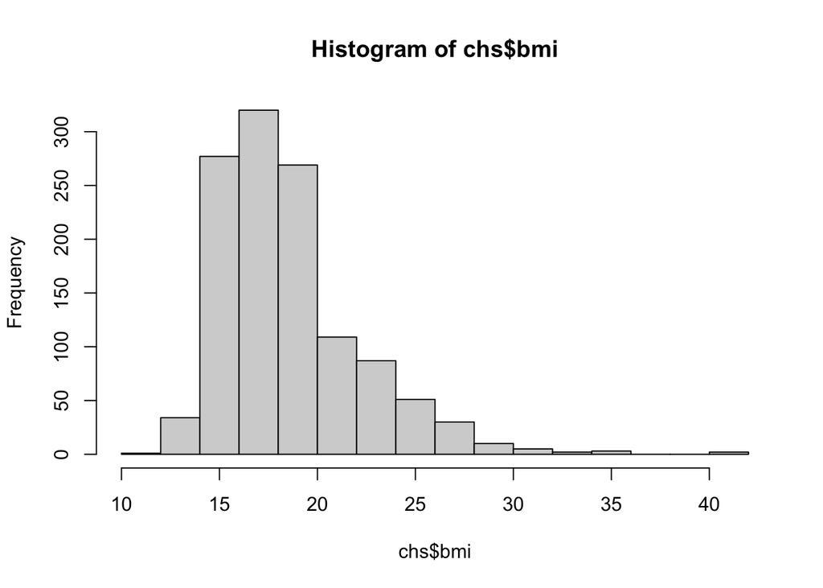

```r
hist(chs$bmi)
```

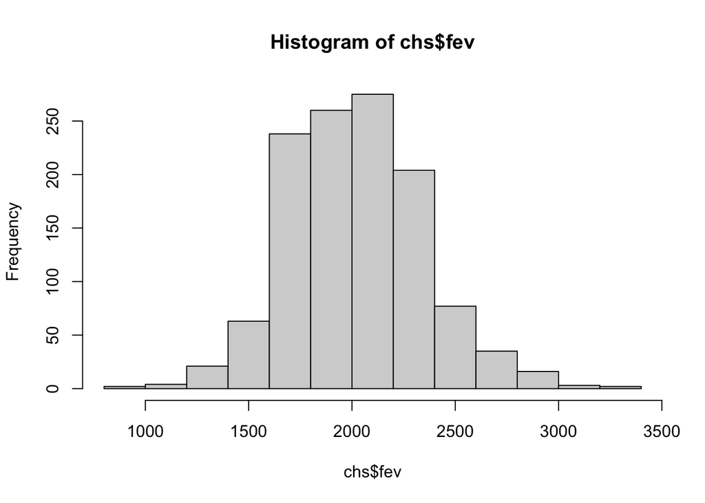

```r
hist(chs$fev)
```

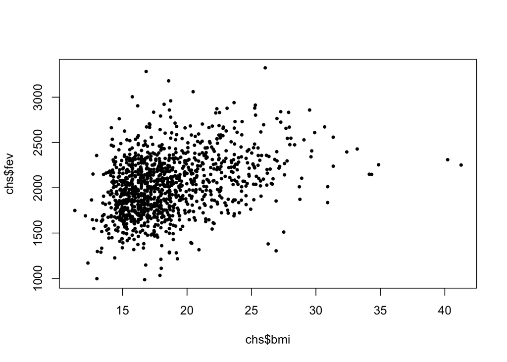

```r
plot(chs$bmi, chs$fev, pch=19, cex=0.5)
```

2. The plot above appears to show some weak correlation between the variables.

   What is the association between smoke and gas exposure and FEV?

FEV EDA done above.

```r
head(chs$smoke_gas_exposure)
```

```
[1] "Neither Smoke nor Gas Stove" "Neither Smoke nor Gas Stove"
[3] "Neither Smoke nor Gas Stove" "Gas Stove Only"
[5] "Gas Stove Only"              "Gas Stove Only"
```

```r
tail(chs$smoke_gas_exposure)
```

```
[1] "Neither Smoke nor Gas Stove" "Neither Smoke nor Gas Stove"
[3] "Gas Stove Only"              "Gas Stove Only"
[5] "Gas Stove Only"              "Neither Smoke nor Gas Stove"
```

Distribution of smoke and gas exposure performed above.

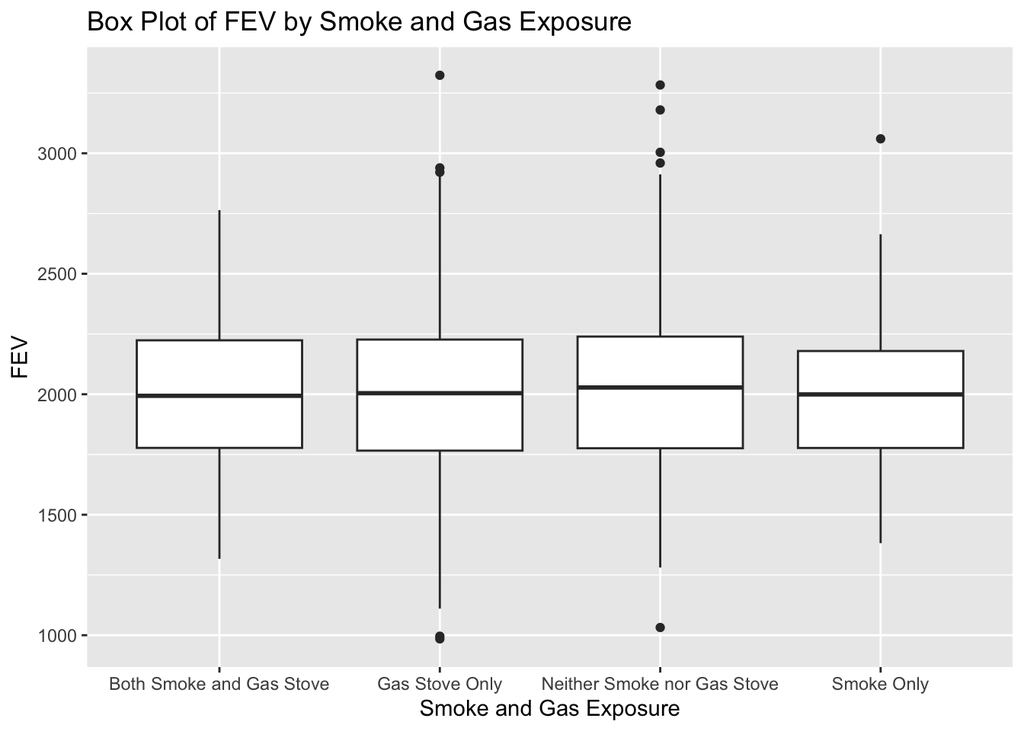

```r
library(ggplot2)
ggplot(chs, aes(x = smoke_gas_exposure, y = fev)) +
  geom_boxplot() +
  labs(
    title = "Box Plot of FEV by Smoke and Gas Exposure",
    x = "Smoke and Gas Exposure",
    y = "FEV"
  )
```

There is not a very clear association between exposure to smoke and/or gas stove and FEV.

3. What is the association between PM2.5 exposure and FEV?

FEV EDA done above.

```r
head(chs$pm25_mass)
```

```
[1] 8.74 8.74 8.74 8.74 8.74 8.74
```

```r
tail(chs$pm25_mass)
```

```
[1] 22.46 22.46 22.46 22.46 22.46 22.46
```

```r
summary(chs$pm25_mass)
```

```
   Min. 1st Qu.  Median    Mean 3rd Qu.    Max.
  5.960   7.615  10.545  14.362  20.988  29.970
```

```r
average_pm25_mass <- mean(chs$fev, na.rm = TRUE)
print(average_pm25_mass)
```

```
[1] 2014.647
```

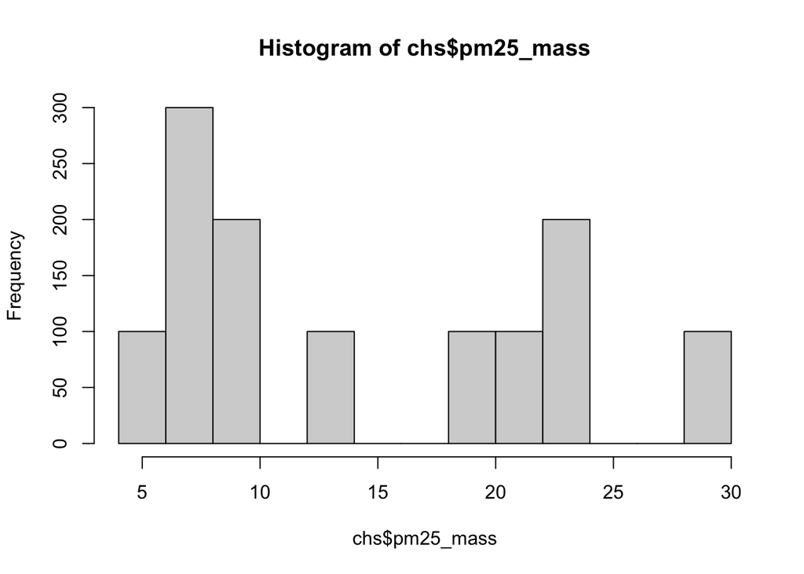

```r
hist(chs$pm25_mass)
```

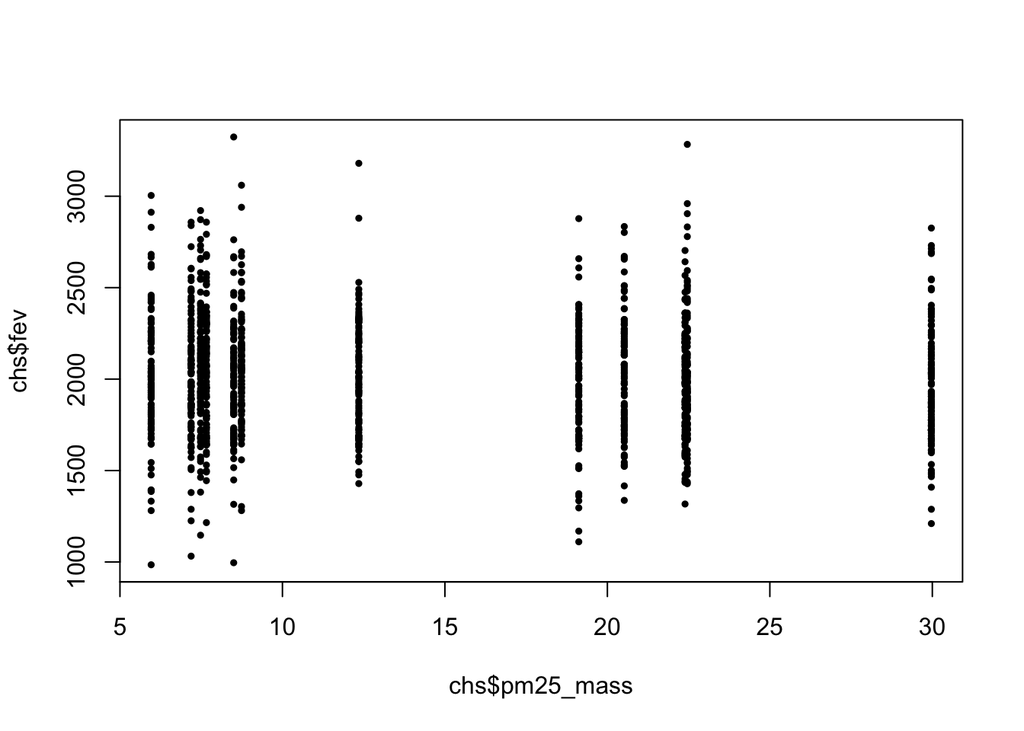

```r
plot(chs$pm25_mass, chs$fev, pch=19, cex=0.5)
```

There does not appear to be a clear association between PM2.5 and FEV.

## Visualization

1. Facet plot showing scatterplots with regression lines of BMI vs FEV by "townname".

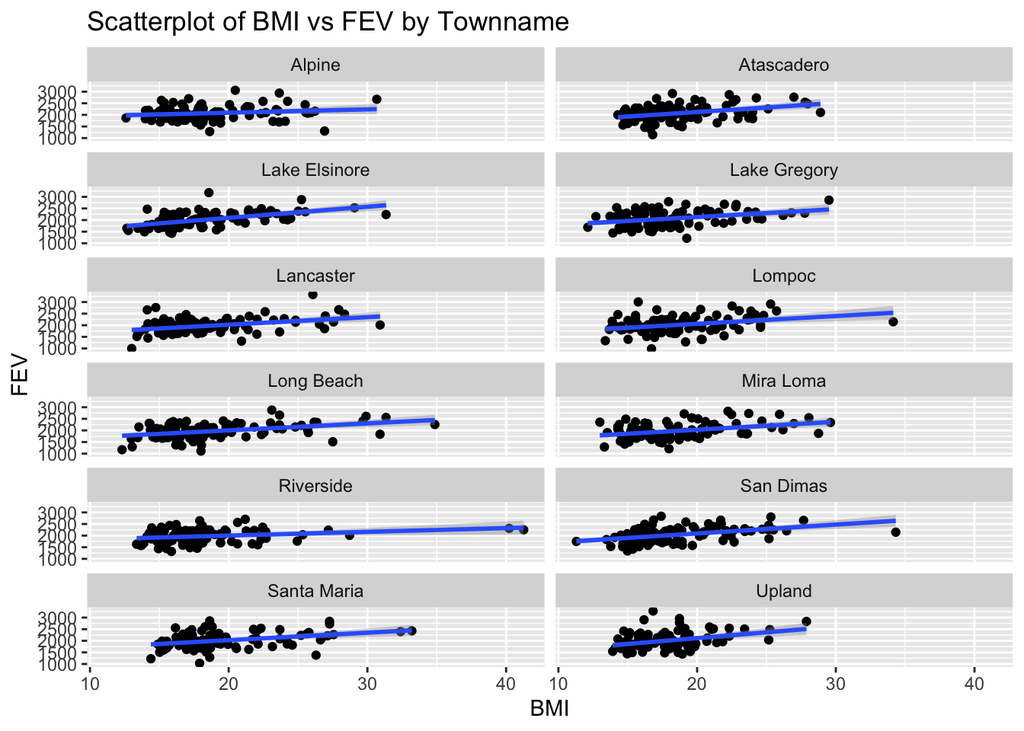

```r
ggplot(chs, aes(x = bmi, y = fev)) +
  geom_point() +
  geom_smooth(method = "lm") +
  labs(
    title = "Scatterplot of BMI vs FEV by Townname",
    x = "BMI",
    y = "FEV"
  ) +
  facet_wrap(~ townname, ncol = 2)
```

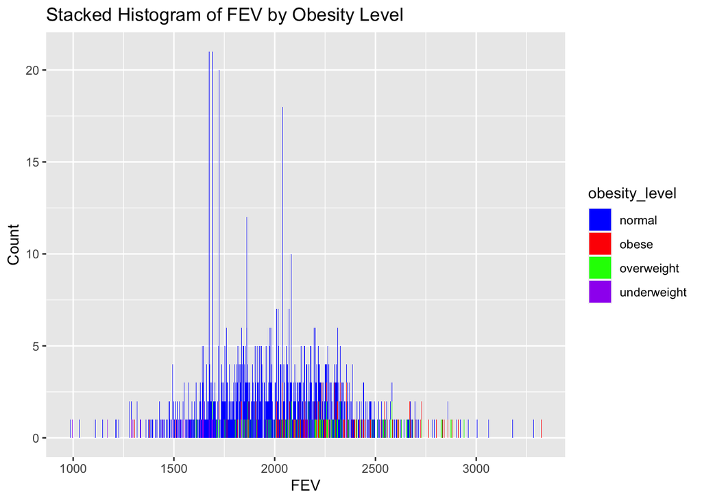

```r
library(RColorBrewer)
ggplot(chs, aes(x = fev, fill = obesity_level)) +
  geom_histogram(binwidth = 2.0) +
  labs(
    title = "Stacked Histogram of FEV by Obesity Level",
    x = "FEV",
    y = "Count"
  ) +
  scale_fill_manual(values = c("obese" = "red", "normal" = "blue", "overweight" = "green", "underweight" = "purple"))
```

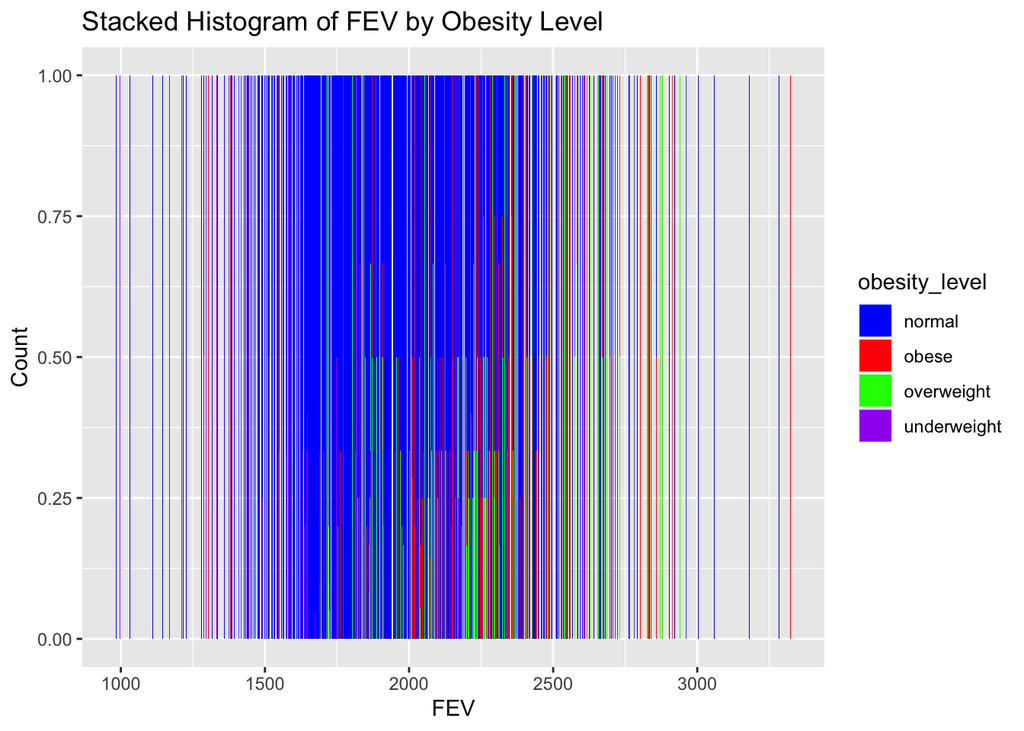

```r
library(RColorBrewer)
ggplot(chs, aes(x = fev, fill = obesity_level)) +
  geom_histogram(binwidth = 2.0, position = "fill") +
  labs(
    title = "Stacked Histogram of FEV by Obesity Level",
    x = "FEV",
    y = "Count"
  ) +
  scale_fill_manual(values = c("obese" = "red", "normal" = "blue", "overweight" = "green", "underweight" = "purple"))
```

3. Barchart of BMI by smoke/gas exposure.

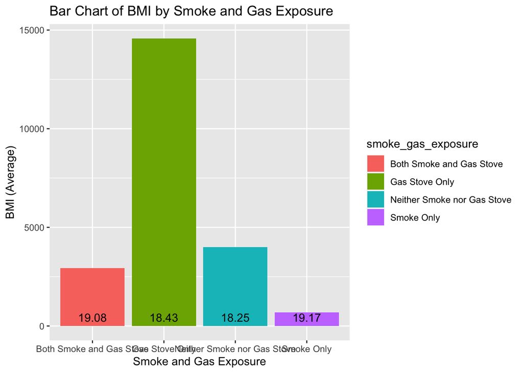

```r
library(ggplot2)

ggplot(chs, aes(x = smoke_gas_exposure, y = bmi, fill = smoke_gas_exposure)) +
  geom_bar(stat = "identity") +
  stat_summary(
    fun.y = "mean",
    geom = "text",
    aes(label = round(..y.., 2)),
    vjust = -0.5,
    position = position_dodge(width = 0.9)
  ) +
  labs(
    title = "Bar Chart of BMI by Smoke and Gas Exposure",
    x = "Smoke and Gas Exposure",
    y = "BMI (Average)"
  )
```

Directions unclear; listed average BMI at bottom of each bar.

4. Statistical summary graphs of FEV by BMI and FEV by smoke/gas exposure category.

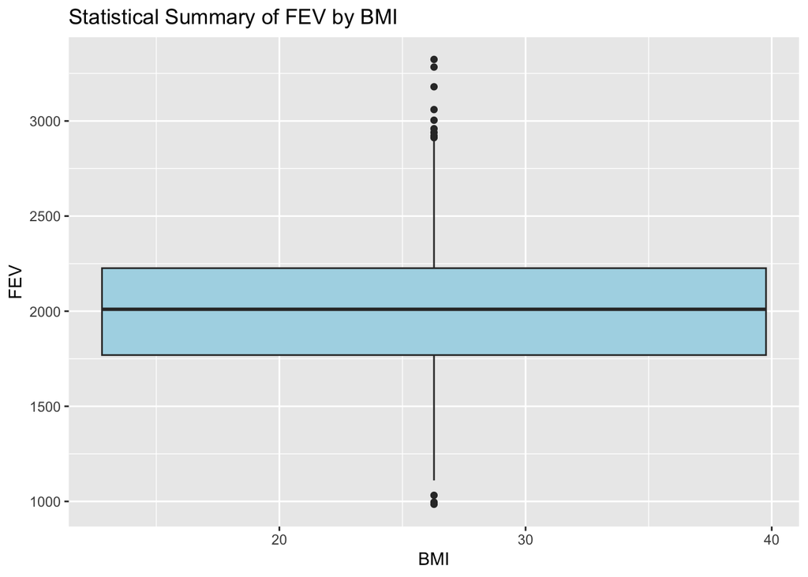

```r
library(ggplot2)
ggplot(chs, aes(x = bmi, y = fev)) +
  geom_boxplot(fill = "lightblue") +
  labs(
    title = "Statistical Summary of FEV by BMI",
    x = "BMI",
    y = "FEV"
  )
```

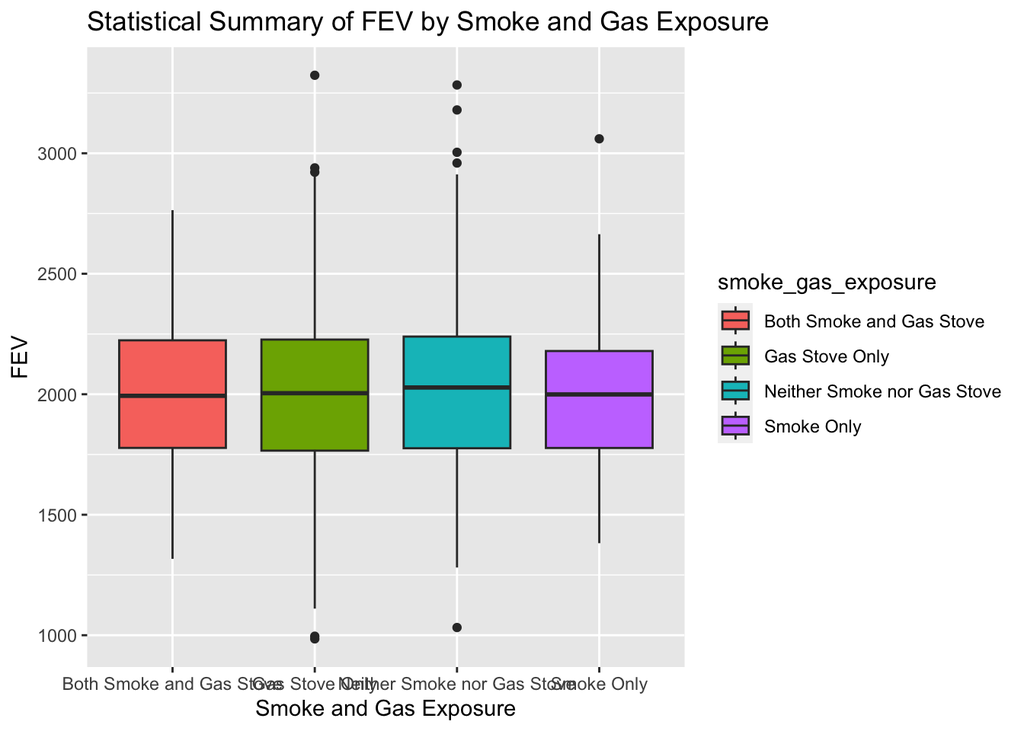

```r
ggplot(chs, aes(x = smoke_gas_exposure, y = fev, fill = smoke_gas_exposure)) +
  geom_boxplot() +
  labs(
    title = "Statistical Summary of FEV by Smoke and Gas Exposure",
    x = "Smoke and Gas Exposure",
    y = "FEV"
  )
```

5. A leaflet map showing the concentrations of PM2.5 mass in each of the CHS communities.

```r
library(leaflet)
```

```r
map <- leaflet(data = chs) %>%
  addTiles()
map <- map %>%
  addCircleMarkers(
    lat = ~lat,
    lng = ~lon,
    radius = 4,
    color = "red",
    fillOpacity = 0.7,
    popup = ~paste("Community: ", townname, "<br>PM2.5 Mass: ", pm25_mass, " µg/m³"),
    label = ~townname
  )
map <- map %>%
  setView(lng = -119.4179, lat = 36.7783, zoom = 6)
map
```

[interactive chart not shown]

6. Choose a visualization to examine whether PM2.5 mass is associated with FEV.

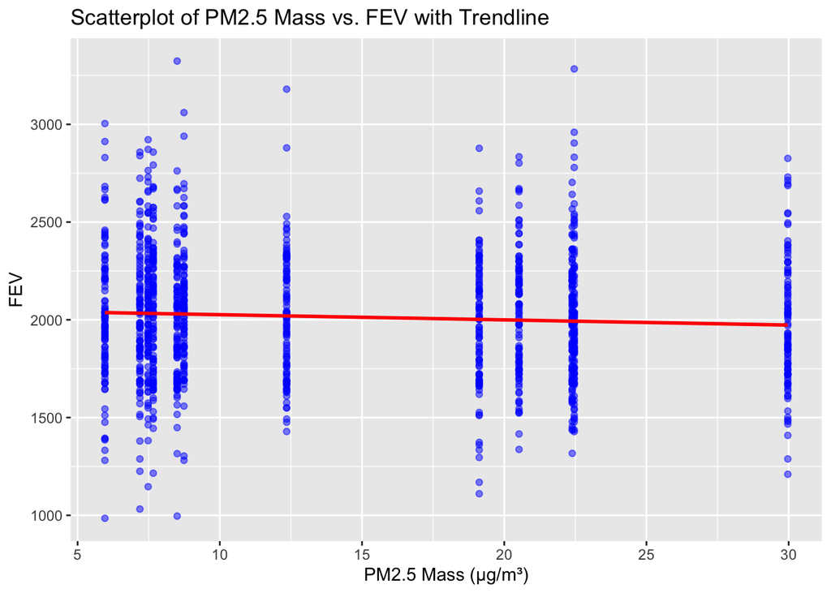

```r
library(ggplot2)
ggplot(chs, aes(x = pm25_mass, y = fev)) +
  geom_point(color = "blue", alpha = 0.5) +
  geom_smooth(method = "lm", se = FALSE, color = "red") +
  labs(
    title = "Scatterplot of PM2.5 Mass vs. FEV with Trendline",
    x = "PM2.5 Mass (µg/m³)",
    y = "FEV"
  )
```

The trendline demonstrates that there may be a very small negative correlation between the two variables.